# Contact Mega-Analysis — Project Status

Population, data, and coding progress across the project

Published

July 5, 2026

Welcome — this is the shared status page for our intergroup-contact mega-analysis, so the whole team can see where the project stands at a glance: how many datasets are included, what has been acquired and coded so far, and what the combined population looks like.

## At a glance

340

Included datasets

1,020,831

Participants

across 167 datasets with recorded N

44

Countries

213

Variables extracted

status = done

192

Analysis-eligible

≥1 contact & ≥1 attitude var

21

Import script written

Counts describe the **included** population (340 datasets); 7 more are pending inclusion.

**About this page & how it updates**

Figures are drawn from the project inventory. To refresh the published page, run `bash 11_code_helpers/deploy_dashboard.sh`.

## From data to analysis-ready

Datasets reach analysis-readiness along **two independent tracks** — *acquiring the data* and *coding the variables*. These are not sequential gates: 23 datasets are coded but not yet in hand, and 65 are in hand but uncoded. A dataset is **ready to import** only when it clears both tracks and carries the contact + attitude variables an effect size needs.

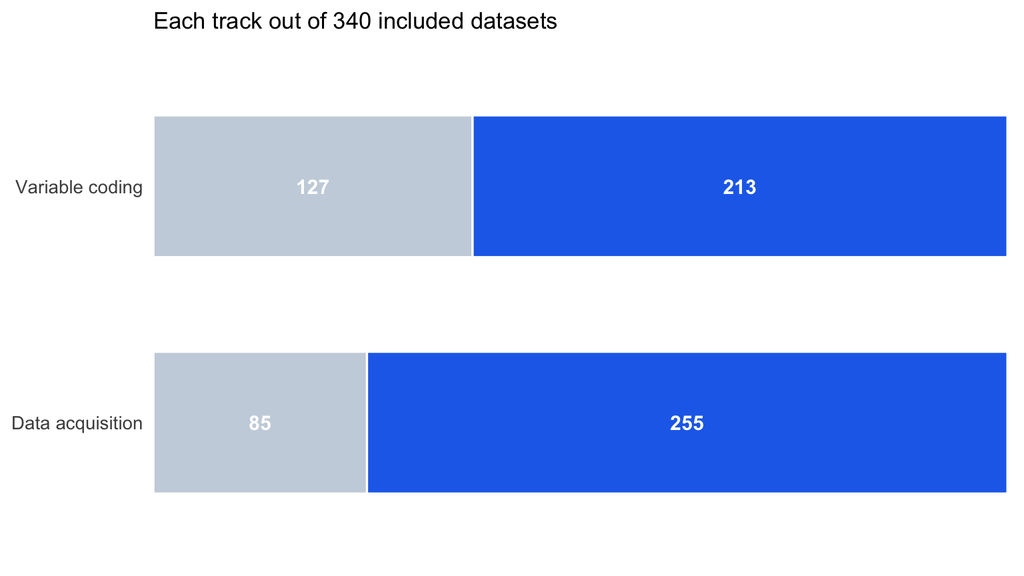

Once a dataset clears **both** tracks, it moves through the sequential downstream steps — writing an import script, then extracting effect sizes:

174

Ready to import

data in hand + coded + eligible

→

21

Import script written

→

0

Effect size extracted

beyond pilot

**Note**

174 datasets are ready to import. So far 21 have an import script, and effect-size extraction is still at the pilot stage. These downstream steps are the current focus of ongoing work.

## Coding & data-availability status

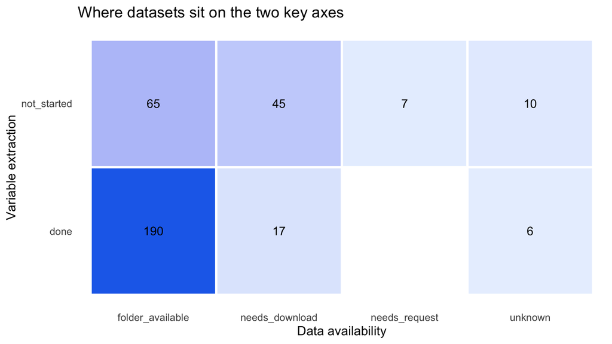

## Coding provenance

The variable coding is **human-coded throughout**. Original coder attribution was recovered from the pre-rebuild `Dataset inventory.xlsx` and written back to the Sheet (`coder_attribution.csv`); newer datasets are attributed live in the app.

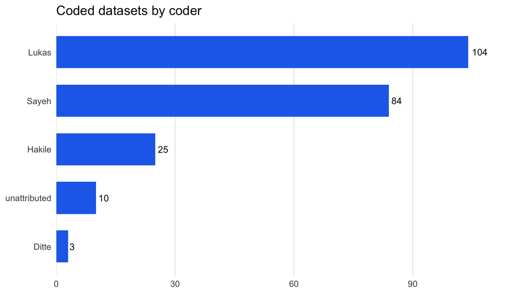

The one set of machine-generated material is **21 `chatgpt_extraction.xlsx` drafts** for datasets that were never imported into the inventory. These are kept separate from the human-coded corpus and remain candidates for a documented, validated re-extraction pipeline.

**Note**

A review of the remaining *unattributed* datasets surfaced some recurring coding issues — for example, ingroup contact coded as outgroup, and neighbourhood-composition or attitude items coded as contact. Clean datasets were attributed; flagged ones are queued for re-coding.

## Population composition

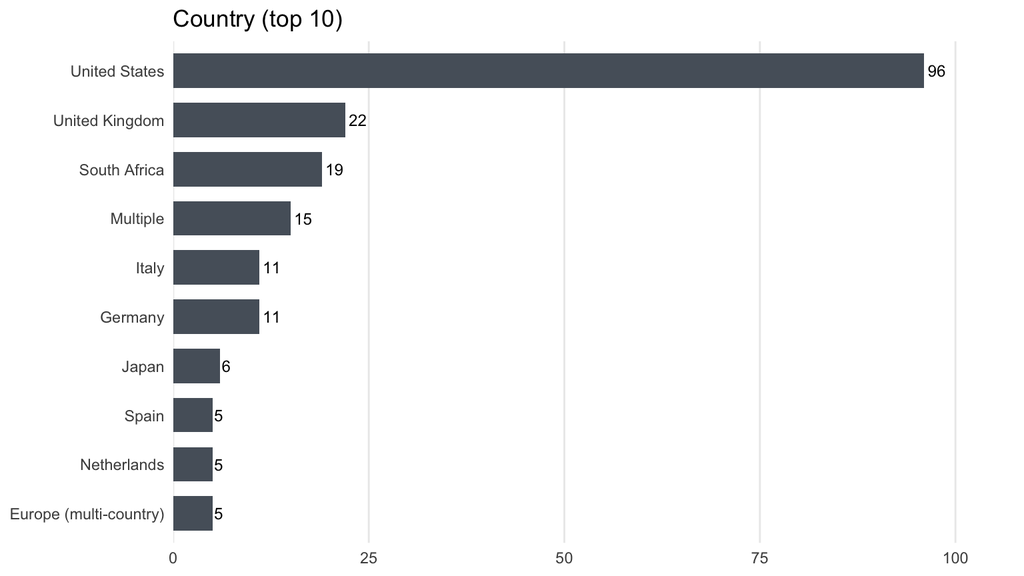

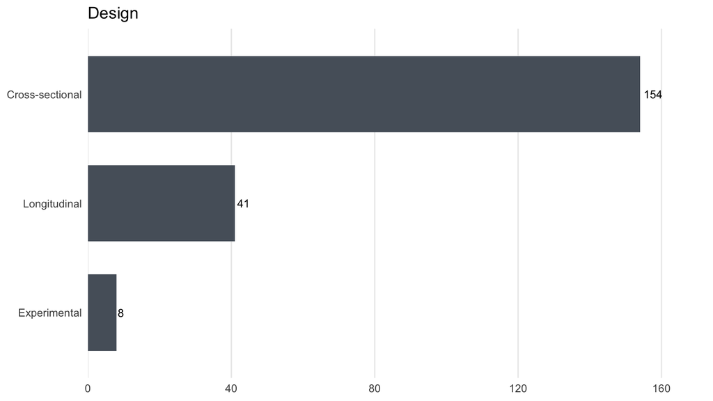

## Every dataset (searchable)

Search or filter by any column, and sort to see where each dataset sits in the pipeline.

| Tag | Dataset | country | design | N | Data | Coded | Eligible | Import | Effect |
| --- | --- | --- | --- | --- | --- | --- | --- | --- | --- |
| BRS_2007 | Dataset from: "Baylor Religion Survey" 2007 | United States | Cross-sectional | 1184 | needs_download | done | yes |  |  |
| abcc_2020 | ABC News/Washington Post Poll: July 2020 Coronavirus | United States | Cross-sectional | 1006 | needs_download | done | yes |  |  |
| abcr_1997 | Dataset from: "ABC News/Washington Post Race and Crime Po... | United States | Cross-sectional | 1137 | folder_available | done | yes |  |  |
| allbus_19802018 | ALLBUS | Germany | Cross-sectional | 68161 | folder_available | done | yes | yes |  |
| amvalues_2010 | PRRI 2010 American Values Survey | United States | NA | NA | folder_available | done | yes |  |  |
| amvalues_2022 | PRRI 2022 American Values Survey | United States | NA | NA | folder_available | done | yes |  |  |
| amvalues_wave3 | PRRI August AVA Wave 3 | NA | NA | NA | folder_available | done | yes |  |  |
| anes_1964 |  | NA | NA | NA | folder_available | done | yes |  |  |
| anes_1968 | Dataset from: "ANES 1968 Time Series Study (ICPSR 7281)" | United States | Longitudinal | 1673 | folder_available | done | yes |  |  |
| anes_1970 | Dataset from: "ANES 1970 Time Series Study (ICPSR 7298)" | United States | Longitudinal | 1694 | folder_available | done | yes |  |  |

[output cut: 330 more lines]